## Task 19: Spatial Data and Measure Data

### Background

Up to this point, we have dealt with data that fits into the tidy format without much effort. Spatial data has many complicating factors that have made handling spatial data in R complicated. Big strides are being made to make spatial data tidy in R. However; we are in the middle of the transition.

We will use `library(USAboundaries)`, `library(ggrepel)`, and `library(sf)` to make a map of the US and show the top 3 largest cities in each state. Specifically, you will use `library(ggplot2)` and the function `geom_sf()` to recreate the provided image.

- Homework Schedule

### Reading

This reading will help you complete the tasks below.

- o [Using SF package with tidyverse](https://byuistats.github.io/M335/spatial_reading.html)
- o [SF R package](https://r-spatial.github.io/sf/)
- o [USAboundaries R Package](https://github.com/ropensci/USAboundaries)
- o [Video on spatial datums](https://www.youtube.com/watch?v=xKGlMp__jog)
- o [Video 2 on spatial datums](https://www.youtube.com/watch?v=kXTHaMY3cVk)

### Tasks

- [ ] Take notes on your reading of the new R package in the README.md or in a ‘.R’ script in the class task folder
- [ ] Create a `.png` image that closely matches my example
  - [ ] Note that `fill = NA` in `geom_sf()` will not fill the polygons with a grey color
  - [ ] Note that `library(USAboundaries)` has three useful functions - `us_cities()`, `us_states()`, and `us_counties()`
- [ ] Save your script and `.png` files to GitHub

## Image

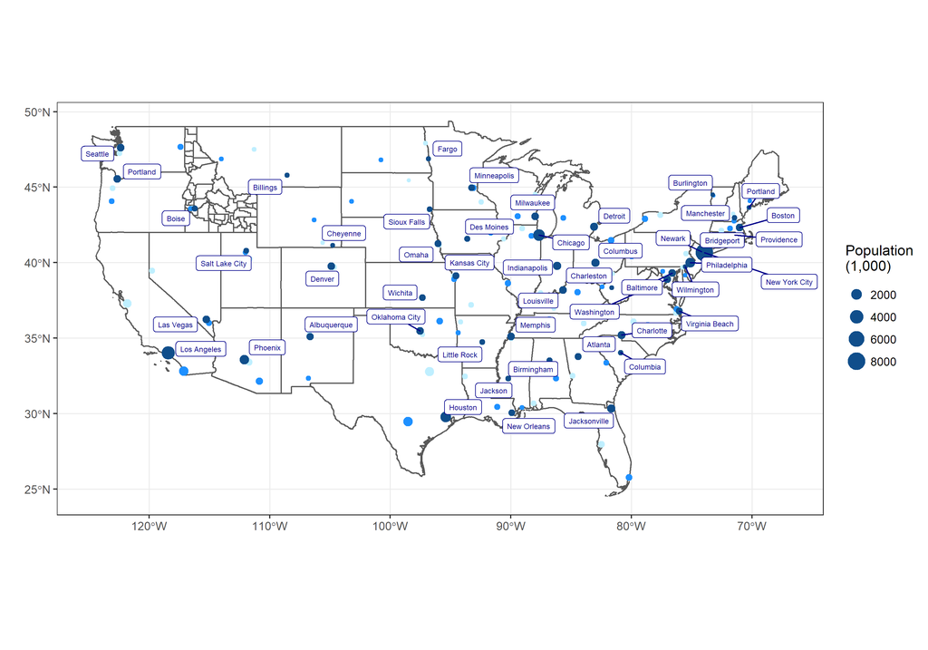